# Project 3: Predicting Winners in Soccer Matches

Predicting the outcome of a sporting event is a challenging task, so much so that an entire industry exists to relieve those who believe they can do so of their money. Despite the challenging nature of the task, there are a few people who manage to make their living (and a very good living at that!) making predictions and betting on the outcomes. Your job is to try your hand at this with a basic model.

## The Data

For this project, you are going to use a large *relational database* of publicly available information on European soccer matches that is available [here](https://www.kaggle.com/hugomathien/soccer/kernels). This database is a SQLite database. A relational database is a data structure which contains several related tables, where each table is similar to a dataframe. There are a couple of advantages to having the data in a database: for one thing, you can 'peek' at the data without loading it all into memory. Also, databases tend to be strongly typed, so that you always know the type of data that is loaded in each column (though actually SQLite is much looser in this regard than other database software).

## The Objective(s)

Below, you will tag every match with a 1 for home team win or draw and a 0 for away team win. Your goal is to build a model to predict whether the game is a home team win or draw or an away team win. You must:

1. Explore the dataset. What appears to correlate with home team wins/losses? What is missing?
2. Separate the data into a set for training (building the model) and testing. The test set size should not be more than 20% of the full dataset.
3. Build a model to predict who wins. To determine the quality of the model, assess the model by calculating the accuracy. You can write a function to do this or use scikit-learn's `accuracy_score`, which is in the `metrics` submodule.
4. Build a couple of different models (creating a different model means using a different set of predictor variables). Which performs the best on the held-out testing dataset? Bonus points for creativity and thoroughness! You must create and test a minimum of three different models for full credit.

## Teams

1. Evan Royer, Briana Garcia (Durham)
2. Evan O'Reilly, Jacob Mechaber (Durham)
3. Patrick Donovan, Kelvin Nguyen, Robert Patenaude
4. Aaron Broady, Andrew Meyer, Wesley Couturier, Ryan Kiessling
5. Angus Jameson, Danielle LeBoeuf, Craig Vignault
6. Brent Groden, Stephen McCarter, Aurora VanDeWater

Consider using Git/Github to share and manage your work!

## Due Date

Due by Tuesday, May 2, 3:39 PM. Submit as an HTML file on myCourses.

## Final Thoughts

This is an extremely challenging prediction task. To get a sense of how hard it is, start by making a couple absolutely dumb baseline models: predicting always home team wins, for instance, or predicting wins entirely at random. Measure the accuracy of these models. As you develop more sophisticated models, refer back to these dumb ones. Did your model do better?

This database has been explored quite a bit on kaggle.com. Feel free to use what you see there.

```python
'''
DO NOT CHANGE ANYTHING IN THIS CELL
YOU MUST RUN THIS CELL TO CONTINUE
'''

import numpy as np
import pandas as pd
import matplotlib.pyplot as plt
import sqlite3

%matplotlib inline
plt.style.use('bmh')
```

## Getting the data out of the database

To get data from a database, you must first connect to it from Python. Once you've connected, you then need to create a cursor. A cursor is a temporary memory space where operations can be performed.

```python
'''
CHANGE YOUR PATH IN THE LINE BELOW
'''

path_to_my_database = 'database/database.sqlite'
conn = sqlite3.connect(path_to_my_database)  # connect to database
cur = conn.cursor()  # create cursor
```

## Getting A View of the Database

One way to get an overview of the entire database is to look at the code that created it. This is SQL (Structured Query Language), which you do not know yet, but which is fairly intuitive. We'll execute a command to view the contents of the sqlite_master table, which contains the code that created the underlying tables. Syntax is as follows: first execute, then fetch the results (if you don't fetch them, they exist, but they remain in the cursor's temporary workspace).

```python
'''
DO NOT CHANGE ANYTHING IN THIS CELL
'''

cur.execute("select * from sqlite_master where type == 'table';").fetchall()
```

```
[('table',
  'sqlite_sequence',
  'sqlite_sequence',
  4,
  'CREATE TABLE sqlite_sequence(name,seq)'),
 ('table',
  'Player_Attributes',
  'Player_Attributes',
  11,
  'CREATE TABLE "Player_Attributes" (\n\t`id`\tINTEGER PRIMARY KEY AUTOINCREMENT,\n\t`player_fifa_api_id`\tINTEGER,\n\t`player_api_id`\tINTEGER,\n\t`date`\tTEXT,\n\t`overall_rating`\tINTEGER,\n\t`potential`\tINTEGER,\n\t`preferred_foot`\tTEXT,\n\t`attacking_work_rate`\tTEXT,\n\t`defensive_work_rate`…
 ('table',
  'Player',
  'Player',
  14,
  'CREATE TABLE `Player` (\n\t`id`\tINTEGER PRIMARY KEY AUTOINCREMENT,\n\t`player_api_id`\tINTEGER UNIQUE,\n\t`player_name`\tTEXT,\n\t`player_fifa_api_id`\tINTEGER UNIQUE,\n\t`birthday`\tTEXT,\n\t`height`\tINTEGER,\n\t`weight`\tINTEGER\n)'),
 ('table',
  'Match',
  'Match',
  18,
  'CREATE TABLE `Match` (\n\t`id`\tINTEGER PRIMARY KEY AUTOINCREMENT,\n\t`country_id`\tINTEGER,\n\t`league_id`\tINTEGER,\n\t`season`\tTEXT,\n\t`stage`\tINTEGER,\n\t`date`\tTEXT,\n\t`match_api_id`\tINTEGER UNIQUE,\n\t`home_team_api_id`\tINTEGER,\n\t`away_team_api_id`\tINTEGER,\n\t`home_team_goal`\tIN…
 ('table',
  'League',
  'League',
  24,
  'CREATE TABLE `League` (\n\t`id`\tINTEGER PRIMARY KEY AUTOINCREMENT,\n\t`country_id`\tINTEGER,\n\t`name`\tTEXT UNIQUE,\n\tFOREIGN KEY(`country_id`) REFERENCES `country`(`id`)\n)'),
 ('table',
  'Country',
  'Country',
  26,
  'CREATE TABLE `Country` (\n\t`id`\tINTEGER PRIMARY KEY AUTOINCREMENT,\n\t`name`\tTEXT UNIQUE\n)'),
 ('table',
  'Team',
  'Team',
  29,
  'CREATE TABLE "Team" (\n\t`id`\tINTEGER PRIMARY KEY AUTOINCREMENT,\n\t`team_api_id`\tINTEGER UNIQUE,\n\t`team_fifa_api_id`\tINTEGER,\n\t`team_long_name`\tTEXT,\n\t`team_short_name`\tTEXT\n)'),
 ('table',
  'Team_Attributes',
  'Team_Attributes',
  2,
  'CREATE TABLE `Team_Attributes` (\n\t`id`\tINTEGER PRIMARY KEY AUTOINCREMENT,\n\t`team_fifa_api_id`\tINTEGER,\n\t`team_api_id`\tINTEGER,\n\t`date`\tTEXT,\n\t`buildUpPlaySpeed`\tINTEGER,\n\t`buildUpPlaySpeedClass`\tTEXT,\n\t`buildUpPlayDribbling`\tINTEGER,\n\t`buildUpPlayDribblingClass`\tTEXT,\n\t`…
```

## Getting Data From SQLite into Python

As you can see, there are tables like Player_Attributes, Player, Matches, Team_Attributes, and so on. It's easy to bring one of these tables into Pandas with a simple SQL query. In SQL, * is a stand-in for 'everything'. To read a SQL query, keep in mind that you need a connection open, and you need to specify the connection when you write the query.

```python
'''
DO NOT CHANGE ANYTHING IN THIS CELL
'''

players = pd.read_sql_query('select * from Player', conn)  # don't forget to specify the connection
players.head()
```

|  | id | player_api_id | player_name | player_fifa_api_id | birthday | height | weight |
| --- | --- | --- | --- | --- | --- | --- | --- |
| 0 | 1 | 505942 | Aaron Appindangoye | 218353 | 1992-02-29 00:00:00 | 182.88 | 187 |
| 1 | 2 | 155782 | Aaron Cresswell | 189615 | 1989-12-15 00:00:00 | 170.18 | 146 |
| 2 | 3 | 162549 | Aaron Doran | 186170 | 1991-05-13 00:00:00 | 170.18 | 163 |
| 3 | 4 | 30572 | Aaron Galindo | 140161 | 1982-05-08 00:00:00 | 182.88 | 198 |
| 4 | 5 | 23780 | Aaron Hughes | 17725 | 1979-11-08 00:00:00 | 182.88 | 154 |

```python
matches = pd.read_sql_query('select * from Match', conn)  # specify the connection
print(matches.shape)
matches.head()
```

```
(25979, 115)
```

|  | id | country_id | league_id | season | stage | date | match_api_id | home_team_api_id | away_team_api_id | home_team_goal | ... | SJA | VCH | VCD | VCA | GBH | GBD | GBA | BSH | BSD | BSA |
| --- | --- | --- | --- | --- | --- | --- | --- | --- | --- | --- | --- | --- | --- | --- | --- | --- | --- | --- | --- | --- | --- |
| 0 | 1 | 1 | 1 | 2008/2009 | 1 | 2008-08-17 00:00:00 | 492473 | 9987 | 9993 | 1 | ... | 4.00 | 1.65 | 3.40 | 4.50 | 1.78 | 3.25 | 4.00 | 1.73 | 3.40 | 4.20 |
| 1 | 2 | 1 | 1 | 2008/2009 | 1 | 2008-08-16 00:00:00 | 492474 | 10000 | 9994 | 0 | ... | 3.80 | 2.00 | 3.25 | 3.25 | 1.85 | 3.25 | 3.75 | 1.91 | 3.25 | 3.60 |
| 2 | 3 | 1 | 1 | 2008/2009 | 1 | 2008-08-16 00:00:00 | 492475 | 9984 | 8635 | 0 | ... | 2.50 | 2.35 | 3.25 | 2.65 | 2.50 | 3.20 | 2.50 | 2.30 | 3.20 | 2.75 |
| 3 | 4 | 1 | 1 | 2008/2009 | 1 | 2008-08-17 00:00:00 | 492476 | 9991 | 9998 | 5 | ... | 7.50 | 1.45 | 3.75 | 6.50 | 1.50 | 3.75 | 5.50 | 1.44 | 3.75 | 6.50 |
| 4 | 5 | 1 | 1 | 2008/2009 | 1 | 2008-08-16 00:00:00 | 492477 | 7947 | 9985 | 1 | ... | 1.73 | 4.50 | 3.40 | 1.65 | 4.50 | 3.50 | 1.65 | 4.75 | 3.30 | 1.67 |

5 rows × 115 columns

## Complex Queries

You can bring in selected subsets of the database using more complex SQL queries. If you know SQL already, this may be useful. We won't have time to go into complex SQL queries, but it's worth your while to read a little bit about the language; after all, SQL is one of the top languages for data science in its own right. See [this non-python specific SQLite tutorial](https://www.tutorialspoint.com/sqlite/) for an introduction. Fortunately, this dataset is small enough that you should be able to bring most/all of it into memory and thereby work almost entirely in Python.

## Labeling The Matches

The dataset currently doesn't contain a column stating who won and who lost. You'll need to add that. To do so, you can do something like below. You may group draws with home team wins.

```python
'''
DO NOT CHANGE ANYTHING IN THIS CELL
'''

matches['home_team_win_or_draw'] = 0
matches.loc[matches['home_team_goal'] >= matches['away_team_goal'], 'home_team_win_or_draw'] = 1
```

# Good Luck!

```python
# your code here
# I wanted this variable for comparisons later
unfiltered_avg = sum(matches['home_team_win_or_draw']) / matches['home_team_win_or_draw'].count()
print(unfiltered_avg)
```

```
0.712614034412
```

# 1. Explore the dataset. What appears to correlate with home team wins/losses? What is missing?

First, we need to have our data be solely numeric. Andrew made a great observation that if we convert the data into a pandas DataFrame and ask for the correlation coefficients, it automatically has a way of handling non-numeric data.

```python
class_ref = matches.T[0][77] #used to reference non-numeric data type

# your code here
Features_matches = pd.DataFrame(matches)
correlation_set = Features_matches.corr()['home_team_win_or_draw'].sort_values()
print(correlation_set[-10:-1])
```

```
LBA                      0.255476
SJA                      0.256533
B365A                    0.259679
BSA                      0.260677
BWA                      0.263652
GBA                      0.267151
IWA                      0.269143
home_team_goal           0.464327
home_team_win_or_draw    1.000000
Name: home_team_win_or_draw, dtype: float64
```

As you can see however, the highest correlations between the home-team-win-or-draw are coming out to be whether or not a particular team wins at an away game, which makes no sense. These away team counts aren't actually used to determine the success of another team, in fact they are primarily used in betting and gambling statistics.

For the actual data, we need to use team attributes to define the actual quality of a team versus another. In the next cell, Awesome Andrew calculated the top three attributes that make or break a team to win.

```python
team_attributes = pd.read_sql_query('select * from Team_Attributes', conn)  # don't forget to specify the connection

win_draw_team = matches['home_team_win_or_draw'].groupby(matches['home_team_api_id'])
ratio_win_home_team = win_draw_team.apply(lambda x: x.sum() / len(x))

team_buildUpPlaySpeed = team_attributes['buildUpPlaySpeed'].groupby(team_attributes['team_api_id']).mean()
team_buildUpPlayDribbling = team_attributes['buildUpPlayDribbling'].groupby(team_attributes['team_api_id']).mean()
team_buildUpPlayPassing = team_attributes['buildUpPlayPassing'].groupby(team_attributes['team_api_id']).mean()
team_chanceCreationPassing = team_attributes['chanceCreationPassing'].groupby(team_attributes['team_api_id']).mean()
team_chanceCreationCrossing = team_attributes['chanceCreationCrossing'].groupby(team_attributes['team_api_id']).mean()
team_chanceCreationShooting = team_attributes['chanceCreationShooting'].groupby(team_attributes['team_api_id']).mean()
team_defencePressure = team_attributes['defencePressure'].groupby(team_attributes['team_api_id']).mean()
team_defenceAggression = team_attributes['defenceAggression'].groupby(team_attributes['team_api_id']).mean()
team_defenceTeamWidth = team_attributes['defenceTeamWidth'].groupby(team_attributes['team_api_id']).mean()

d = {'team_buildUpPlaySpeed' : pd.Series(team_buildUpPlaySpeed),
'team_buildUpPlayDribbling' : pd.Series(team_buildUpPlayDribbling),
'team_buildUpPlayPassing' : pd.Series(team_buildUpPlayPassing),
'chanceCreationPassing' : pd.Series(team_chanceCreationPassing),
'chanceCreationCrossing' : pd.Series(team_chanceCreationCrossing),
'chanceCreationShooting' : pd.Series(team_chanceCreationShooting),
'defencePressure' : pd.Series(team_defencePressure),
'defenceAggression' : pd.Series(team_defenceAggression),
'defenceTeamWidth' : pd.Series(team_defenceTeamWidth),
'ratio_win_home_team' : pd.Series(ratio_win_home_team)}

df = pd.DataFrame(d)

correlations = df.corr()['ratio_win_home_team'].sort_values(ascending = False)
print(correlations[1:4])
```

```
defencePressure           0.256836
chanceCreationShooting    0.204038
chanceCreationPassing     0.126988
Name: ratio_win_home_team, dtype: float64
```

With the knowing of what are the top three correlatons, we now need to ask ourselves 'How much of the data is missing?' Below, we check for null values in each column.

```python
print(team_attributes['buildUpPlaySpeed'].isnull().sum())
print(team_attributes['buildUpPlayDribbling'].isnull().sum())
print(team_attributes['buildUpPlayPassing'].isnull().sum())
print(team_attributes['chanceCreationPassing'].isnull().sum())
print(team_attributes['chanceCreationCrossing'].isnull().sum())
print(team_attributes['chanceCreationShooting'].isnull().sum())
print(team_attributes['defencePressure'].isnull().sum())
print(team_attributes['defenceAggression'].isnull().sum())
print(team_attributes['defenceTeamWidth'].isnull().sum())
print()
print(team_attributes['id'].count())
```

```
0
969
0
0
0
0
0
0
0

1458
```

It seems as though there's quite a bit of information missing from the attribute 'buildUpPlayDribbling', approximately 969/1458 = 0.664610 or 66.4610%. But luckily for us it seems as though it is not in the top three correlations for home team wins or draws, and if we were to simply add the mean to the null values, the difference between the two is staggeringly small in comparison. See correlation below

```python
#print(df.T[1601])
df_2 = df['team_buildUpPlayDribbling'].fillna(df['team_buildUpPlayDribbling'].mean())
df_2.corr(other=df['team_buildUpPlayDribbling'])
```

```
0.99999999999999978
```

```python
df['team_buildUpPlayDribbling'] = df['team_buildUpPlayDribbling'].fillna(df['team_buildUpPlayDribbling'].mean())
df.corr()['ratio_win_home_team'].sort_values(ascending = False)
```

```
ratio_win_home_team          1.000000
defencePressure              0.256836
chanceCreationShooting       0.204038
chanceCreationPassing        0.126988
defenceAggression            0.120903
defenceTeamWidth             0.089242
team_buildUpPlayDribbling    0.074733
chanceCreationCrossing       0.055389
team_buildUpPlaySpeed        0.030098
team_buildUpPlayPassing     -0.284132
Name: ratio_win_home_team, dtype: float64
```

# 2. Separate the data into a set for training (building the model) and testing. The test set size should not be more than 20% of the full dataset.

```python
numOfMatchesPerTeam = matches['home_team_api_id'].value_counts().sort_values(ascending=False)
numOfMatchesWonPerTeam = matches.loc[matches['home_team_win_or_draw'] == 1, 'home_team_api_id'].value_counts().sort_values(ascending=False)
names = numOfMatchesPerTeam.index.values
ratios = {}

for i in range(len(names)):
    temp = numOfMatchesWonPerTeam[names[i]] / [numOfMatchesPerTeam[names[i]]]
    ratios[names[i]] = temp[0]# = temp_2[0]

ratios = pd.Series(ratios)
ratios.sort_values(ascending=False)
#ratios = temp['home_team_api_id'] / numOfMatchesPerTeam['home_team_api_id']
```

```
9773      0.951613
9772      0.943548
8635      0.943396
9925      0.940789
8634      0.940789
8593      0.933824
8633      0.921053
8548      0.907895
9823      0.904412
8640      0.904412
9931      0.902098
9885      0.894040
8455      0.888158
9875      0.886667
9847      0.881579
```

[output cut: 47 more lines]

In the above, Wesley managed to organize every team sorted based on the ratio to the wins vs total games. This can give us a sense of direction when it comes to comparing our models of team attributes to individual teams to see if they have anything in common with the attributes we believe attribute to a high successful team.

Below we separate our current model into a 80 / 20 train and test.

```python
from sklearn.datasets import make_classification
from sklearn.metrics import accuracy_score as acc
from sklearn.linear_model import LinearRegression
from sklearn.linear_model import LogisticRegression
from sklearn.model_selection import train_test_split
import matplotlib.pyplot as plt
from sklearn.metrics import mean_squared_error as mse
import warnings
warnings.filterwarnings('ignore')

features = df[['defencePressure', 'chanceCreationShooting', 'chanceCreationPassing']]
target = df['ratio_win_home_team']

Xtr, Xte, ytr, yte = train_test_split(features, target, test_size = 0.2, random_state = 0)

#Using only the training data, let's make a few graphs to visually determine if there's a correlation
all_data = np.hstack([Xtr, ytr.reshape(-1, 1)])
df_2 = pd.DataFrame(all_data)

#print(df_2)
```

```
'\nprint(mean_squared_error(ytr, model_1.predict(Xtr[:, 12].reshape(-1, 1))))\nprint(mean_squared_error(ytr, model_2.predict(Xtr[:, 5].reshape(-1, 1))))\nprint(mean_squared_error(ytr, model_3.predict(Xtr[:, 10].reshape(-1, 1))))\n'
```

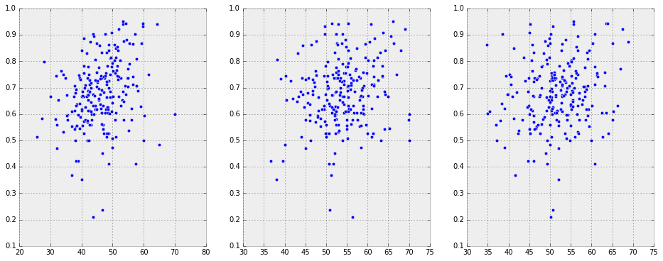

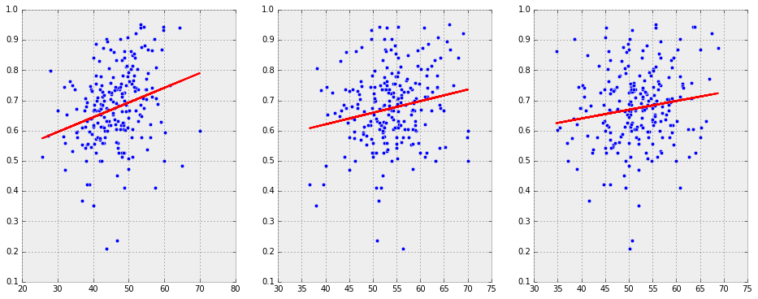

```python
fig, ax = plt.subplots(1, 3, figsize=(16, 6))
ax[0].scatter(df_2[0], df_2[3])
ax[1].scatter(df_2[1], df_2[3])
ax[2].scatter(df_2[2], df_2[3])

Xtr['defencePressure'] = Xtr['defencePressure'][names].fillna(Xtr['defencePressure'].mean())
Xtr['chanceCreationShooting'] = Xtr['chanceCreationShooting'][names].fillna(Xtr['chanceCreationShooting'].mean())
Xtr['chanceCreationPassing'] = Xtr['chanceCreationPassing'][names].fillna(Xtr['chanceCreationPassing'].mean())

# Make the models such that they are geared to the top 3 correlations
model_1 = LinearRegression().fit(Xtr['defencePressure'].values.reshape(-1, 1), ytr)
model_2 = LinearRegression().fit(Xtr['chanceCreationShooting'].values.reshape(-1, 1), ytr)
model_3 = LinearRegression().fit(Xtr['chanceCreationPassing'].values.reshape(-1, 1), ytr)

fig_one, ax_one = plt.subplots(1, 3, figsize=(16, 6))
ax_one[0].scatter(df_2[0], df_2[3])
ax_one[0].plot(df_2[0], model_1.coef_ * df_2[0] + model_1.intercept_, color='red')
ax_one[1].scatter(df_2[1], df_2[3])
ax_one[1].plot(df_2[1], model_2.coef_ * df_2[1] + model_2.intercept_, color='red')
ax_one[2].scatter(df_2[2], df_2[3])
ax_one[2].plot(df_2[2], model_3.coef_ * df_2[2] + model_3.intercept_, color='red')
#plt.plot(x, lm.coef_ * x + lm.intercept_, color='red')
'''
print(mean_squared_error(ytr, model_1.predict(Xtr[:, 12].reshape(-1, 1))))
print(mean_squared_error(ytr, model_2.predict(Xtr[:, 5].reshape(-1, 1))))
print(mean_squared_error(ytr, model_3.predict(Xtr[:, 10].reshape(-1, 1))))
'''
```

# 3. Build a model to predict who wins. To determine the quality of the model, assess the model by calculating the accuracy. You can write a function to do this or use scikit-learn's `accuracy_score`, which is in the `metrics` submodule.

```python
Xte['defencePressure'] = Xte['defencePressure'][names].fillna(Xte['defencePressure'].mean())
Xte['chanceCreationShooting'] = Xte['chanceCreationShooting'][names].fillna(Xte['chanceCreationShooting'].mean())
Xte['chanceCreationPassing'] = Xte['chanceCreationPassing'][names].fillna(Xte['chanceCreationPassing'].mean())

predict_1 = model_1.predict(Xte['defencePressure'].values.reshape(-1, 1))
predict_2 = model_2.predict(Xte['chanceCreationShooting'].values.reshape(-1, 1))
predict_3 = model_3.predict(Xte['chanceCreationPassing'].values.reshape(-1, 1))

#print(yte.count())
#print(Xte['defencePressure'].values.reshape(-1, 1))
#print(yte)

print(mse(yte, predict_1))
print(mse(yte, predict_2))
print(mse(yte, predict_3))
```

```
0.015119208716
0.0147973426706
0.0159008935489
```

```python
def find_accuracy (prediction):
    '''
    DESCRIPTION: Used to find the accuracy between a prediction model and a test model with actual data
    it works by asking ourselves what our real model says about the odds, and then checks to see if the prediction was right
    If it was right, it will get counted into either Alpha or Delta. Then the sum of Alpha and Delta divided by the total number of predictions
    equals to how accurate the prediction was.
    '''
    alpha = 0
    beta = 0
    charlie = 0
    delta = 0

    for a in range(len(prediction)):
        for h in range(yte.count()):
            if yte[yte.index[h]] >= yte[yte.index[a]]:
                if yte[yte.index[h]] >= prediction[a]:
                    alpha += 1
                else:
                    beta += 1
            else:
                if yte[yte.index[h]] >= prediction[a]:
                    charlie += 1
                else:
                    delta += 1

    return((alpha + delta) / 3600)

print(find_accuracy(predict_1))
print(find_accuracy(predict_2))
print(find_accuracy(predict_3))
```

```
0.73
0.7327777777777778
0.7244444444444444
```

As we can see, we have a very small Mean Squared error. So small in fact, I question whether or not the data is accurate. However, this is offset as the accuracy of the models are only about 72%.